# Peer-graded Assignment: Course Project 1

# Introduction

It is now possible to collect a large amount of data about personal movement using activity monitoring devices such as a Fitbit, Nike Fuelband, or Jawbone Up. These type of devices are part of the “quantified self” movement – a group of enthusiasts who take measurements about themselves regularly to improve their health, to find patterns in their behavior, or because they are tech geeks. But these data remain under-utilized both because the raw data are hard to obtain and there is a lack of statistical methods and software for processing and interpreting the data.

This assignment makes use of data from a personal activity monitoring device. This device collects data at 5 minute intervals through out the day. The data consists of two months of data from an anonymous individual collected during the months of October and November, 2012 and include the number of steps taken in 5 minute intervals each day.

First, let’s download the data and save it in your working derictory. We’ll read it into activity dataframe. The following code will do it.

```r
wd<-getwd()
temp<-tempfile()
file1<-paste0(wd,"/activity.csv")
fileURL<-"https://d396qusza40orc.cloudfront.net/repdata%2Fdata%2Factivity.zip"

if (!file.exists(file1))
    {
       download.file(fileURL,temp)
       unzip(temp)
       unlink(temp)
    }
 if ("activity.csv" %in% dir()) activity <- read.csv("activity.csv")
```

### Histogram of the total number of steps taken each day

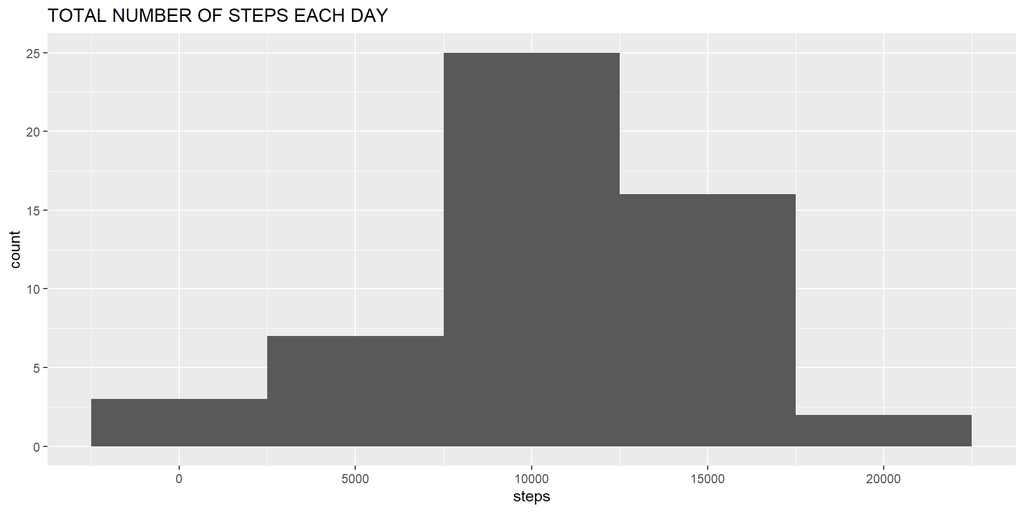

```r
library(ggplot2)
library(dplyr)
activity$date<-as.Date(activity$date)
gr<-activity%>%group_by(date)%>%summarise(steps=sum(steps))
ggplot(gr, aes(x = steps))+
        geom_histogram(binwidth = 5000)+
        ylim(0,25)+
        labs(title = "TOTAL NUMBER OF STEPS EACH DAY")
```

### Mean and median number of steps taken each day

Lets’s calculate mean and median number of steps taking each day. We’ll group dataframe by date first.

```r
library(dplyr)
gr_activity<-activity%>%
                    group_by(date)%>%
                        summarise(tot.steps=sum(steps,na.rm = TRUE))
print(paste("the mean is" , mean(gr_activity$tot.steps, na.rm = TRUE)))
```

```
## [1] "the mean is 9354.22950819672"
```

```r
print(paste("the median is" , median(gr_activity$tot.steps, na.rm = TRUE)))
```

```
## [1] "the median is 10395"
```

### Time series plot of the average number of steps taken

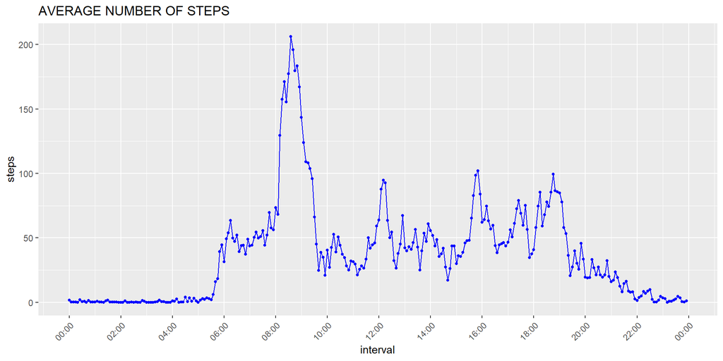

```r
activity$interval <- as.POSIXct(paste(sprintf("%04.0f", activity$interval)), format='%H%M')
ggplot(aes(x = interval, y = steps),data=activity%>%group_by(interval)%>%summarise(steps=mean(steps,na.rm = TRUE)))+
      theme(axis.text.x = element_text(angle = 45, hjust = 1))+
        labs(title = "AVERAGE NUMBER OF STEPS")+
        geom_line(col = "blue")+
        geom_point(shape=16, col="blue", size=1)+
        scale_x_datetime(date_breaks = "2 hours", date_labels = "%H:%M")
```

### The 5-minute interval that, on average, contains the maximum number of steps

Let’s group by interval and avg. the steps.

```r
grint<-activity%>%group_by(interval)%>%summarise(steps=mean(steps, na.rm = TRUE))

print(paste('the 5-minute interval',strftime(grint$interval[which(as.logical(grint$steps==max(grint$steps)))],format="%H:%M"), "contains the maximum number of steps on average",max(grint$steps)))
```

```
## [1] "the 5-minute interval 08:35 contains the maximum number of steps on average 206.169811320755"
```

### Code to describe and show a strategy for imputing missing data

The below code will utilize the following strategy. We will group the dataframe by day of the week and by interval. We will calculate mean of steps in the grouped dataframe and impute the misiing values.

```r
activity$weekdays<-weekdays(activity$date)
impdata<-activity%>%
            group_by(weekdays,interval)%>%
                summarise(imp.steps=mean(steps, na.rm = TRUE))
mactivity<-merge(activity,impdata, by=c("weekdays","interval"), all=TRUE)
mlog<-as.logical(is.na(mactivity$steps))
mactivity$steps[which(mlog)]<-mactivity$imp.steps[which(mlog)]
mactivity<-select(mactivity,"steps","interval","date","weekdays")
gr<-mactivity%>%group_by(date)%>%summarise(steps=sum(steps))
```

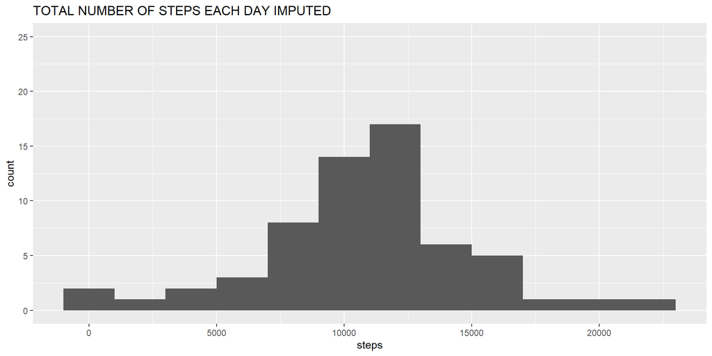

```r
ggplot(gr, aes(x = steps))+
        geom_histogram(binwidth = 2000)+
        ylim(0,25)+
        labs(title = "TOTAL NUMBER OF STEPS EACH DAY IMPUTED")
```

### LET’S CALCULATE MEAN AND MEDIAN OF THE IMPUTED DATA

```r
gr_mactivity<-mactivity%>%
                    group_by(date)%>%
                        summarise(tot.steps=sum(steps,na.rm = TRUE))
print(paste("the mean is" , mean(gr_mactivity$tot.steps, na.rm = TRUE)))
```

```
## [1] "the mean is 10821.2096018735"
```

```r
print(paste("the median is" , median(gr_mactivity$tot.steps, na.rm = TRUE)))
```

```
## [1] "the median is 11015"
```

### Panel plot comparing the average number of steps taken per 5-minute interval across weekdays and weekends

Let’s convert weekdays to 2 factor variable and group the dataframe by interval

```r
#create a vector of weekdays
weekdays1 <- c('Monday', 'Tuesday', 'Wednesday', 'Thursday', 'Friday')
#Use `%in%` and `weekdays` to create a logical vector
#convert to `factor` and specify the `levels/labels`
mactivity$weekdays <- factor((weekdays(mactivity$date) %in% weekdays1),levels=c(FALSE, TRUE),labels=c('weekend', 'weekday'))
data<-mactivity%>%group_by(interval,weekdays)%>%summarise(steps=mean(steps,na.rm = TRUE))
```

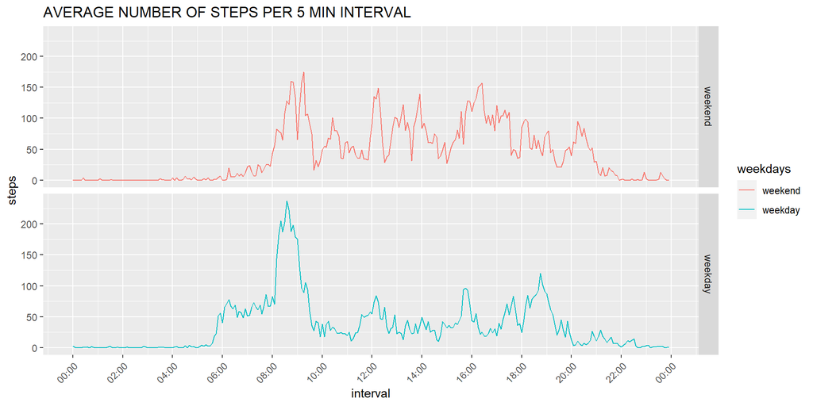

```r
#building plot

dplot<-ggplot(aes(x=interval, y = steps, color=weekdays),data=data)
dplot+geom_line()+facet_grid(rows=vars(weekdays))+labs(title = "AVERAGE NUMBER OF STEPS PER 5 MIN INTERVAL")+
     scale_x_datetime(date_breaks = "2 hours", date_labels = "%H:%M")+
        theme(axis.text.x = element_text(angle = 45, hjust = 1))
```